# **Business Problem Statement**

As a data scientist in our e-Commerce team, one of the significant challenges we're facing is product recommendation and customer segmentation. We need to improve our recommendation system to increase sales while also better understanding our customer behavior to tailor our services to their needs. Our current algorithms are based on transactional data, but we believe incorporating more features, including the time-series aspect of the data, could improve our results.

## **Data Tables**

1. **Table: Customer_Info**
   - CustomerID: Unique ID of the customer
   - Gender: The gender of the customer (M/F)
   - Age: The age of the customer
   - Income: Yearly income of the customer
   - Location: The customer's location
2. **Table: Transactions**
   - TransactionID: Unique ID of the transaction
   - CustomerID: Unique ID of the customer who made the transaction
   - ProductID: Unique ID of the purchased product
   - TransactionTime: Timestamp of the transaction
   - PurchaseAmount: The amount spent on the transaction

## **Questions**

1. How can you segment the customers based on their purchasing behavior over time, considering features such as frequency, recency, and monetary value? What are some insights you can gather from this analysis?**
2. Given the customer and transactions tables, write a SQL query to find the top 5 products in terms of sales for each customer segment identified in Question 1.
3. Build a predictive model to forecast the monthly total sales for the next six months. Justify the choice of your model and discuss how you validated its performance.**
4. A/B testing is often used in e-commerce to test changes to user interfaces and products. If we were to run an A/B test on a new recommendation algorithm, how would you design this test? What metrics would you use to evaluate the results? What is your understanding of the p-value in this context?

```python
# Load the dataframes from csv files
Customer_Info = pd.read_csv("Customer_Info.csv")
Transactions = pd.read_csv("Transactions.csv")
```

## Answer

### Question 1.

**Original Question:**

How can you segment the customers based on their purchasing behavior over time, considering features such as frequency, recency, and monetary value? What are some insights you can gather from this analysis?

**Problem Solving Ideas and Tips:**

To perform customer segmentation based on purchasing behavior over time using RFM (Recency, Frequency, Monetary value) analysis and k-means clustering, we can follow these steps:

**Step 1: Data Preparation** First, we need to prepare our RFM features from the `Transactions` table.

- **Recency**: Calculated as the difference between the latest timestamp in the data and the latest purchase date of each customer.
- **Frequency**: Calculated as the total number of purchases made by each customer.
- **Monetary value**: Calculated as the total purchase amount for each customer.

```python
# Convert 'TransactionTime' to datetime
Transactions['TransactionTime'] = pd.to_datetime(Transactions['TransactionTime'])

# Now you can calculate 'Recency', 'Frequency' and 'Monetary' values
latest_date = Transactions['TransactionTime'].max() + pd.DateOffset(days=1)  # Add an offset of one day
RFM = Transactions.groupby('CustomerID').agg({
    'TransactionTime': lambda x: (latest_date - x.max()).days,  # Recency
    'TransactionID': 'count',  # Frequency
    'PurchaseAmount': 'sum'  # Monetary Value
})

RFM.rename(columns={'TransactionTime': 'Recency',
                   'TransactionID': 'Frequency',
                   'PurchaseAmount': 'Monetary'}, inplace=True)
```

**Step 2: Data Normalization** Since k-means clustering is a distance-based algorithm, we should normalize our data to bring all the features to the same scale.

```python
from sklearn.preprocessing import StandardScaler

scaler = StandardScaler()
RFM_scaled = scaler.fit_transform(RFM)
```

**Step 3: K-Means Clustering** We'll apply the k-means clustering algorithm to segment our customers. To find the optimal number of clusters, we can use the Elbow method, which involves plotting the explained variation as a function of the number of clusters, and picking the elbow of the curve as the number of clusters to use.

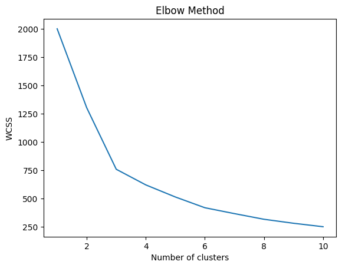

```python
from sklearn.cluster import KMeans
import matplotlib.pyplot as plt

wcss = []
for i in range(1, 11):
    kmeans = KMeans(n_clusters=i, init='k-means++', max_iter=300, n_init=10, random_state=0)
    kmeans.fit(RFM_scaled)
    wcss.append(kmeans.inertia_)

plt.plot(range(1, 11), wcss)
plt.title('Elbow Method')
plt.xlabel('Number of clusters')
plt.ylabel('WCSS')
plt.show()
```

Assuming the optimal number of clusters is 3, we can proceed with the k-means clustering.

```python
kmeans = KMeans(n_clusters=3, init='k-means++', max_iter=300, n_init=10, random_state=0)
cluster_labels = kmeans.fit_predict(RFM_scaled)

RFM['Cluster'] = cluster_labels
```

**Insights**

With our customer segmentation complete, we can now analyze the characteristics of each cluster to derive insights.

- We can create cluster profiles by exploring the central tendencies (mean, median) of the RFM variables. For instance, we might find a cluster of customers who have recent purchases, high frequency, and high monetary value. These could be our "Premium" customers, who are frequent shoppers and spend a lot.
- Comparatively, a cluster with high recency, low frequency, and low monetary value might represent "At-risk" customers who haven't shopped in a while.
- These insights will allow us to develop targeted marketing strategies. For example, we can initiate win-back campaigns for "At-risk" customers and exclusive offers for "Premium" customers to encourage loyalty.

Please note that this analysis assumes that the RFM variables are sufficiently normally distributed. If they are skewed, applying a log transformation or using algorithms that are not affected by the distribution of values (like DBSCAN) may be appropriate.

### Question 2.

**Original Question:**

Given the customer and transactions tables, write a SQL query to find the top 5 products in terms of sales for each customer segment identified in Question 1.

**Problem Solving Ideas and Tips:**

Assuming that the customer segments from the k-means clustering are stored in the `RFM` table, we will first need to join this with the `Transactions` table on the `CustomerID` column. Then, we'll aggregate the data by product and cluster, and use window functions to get the top 5 products for each segment.

```python
import sqlite3

# Create a SQL connection to our SQLite database
con = sqlite3.connect("ecommerce.db")

# Convert pandas dataframes to SQL tables
Customer_Info.to_sql(name='Customer_Info', con=con, if_exists='replace')
Transactions.to_sql(name='Transactions', con=con, if_exists='replace')
RFM.to_sql(name='RFM', con=con, if_exists='replace')
```

```
1000
```

```python
query = """
WITH ProductSales AS (
  SELECT
    t.ProductID,
    r.Cluster,
    SUM(t.PurchaseAmount) AS TotalSales,
    ROW_NUMBER() OVER (PARTITION BY r.Cluster ORDER BY SUM(t.PurchaseAmount) DESC) AS Rank
  FROM Transactions AS t
  JOIN RFM AS r ON t.CustomerID = r.CustomerID
  GROUP BY t.ProductID, r.Cluster
)
SELECT
  ProductID,
  Cluster,
  TotalSales
FROM ProductSales
WHERE Rank <= 5;
"""

# Run the SQL query
top_products_per_segment = pd.read_sql_query(query, con)
top_products_per_segment
```

|  | ProductID | Cluster | TotalSales |
| --- | --- | --- | --- |
| 0 | 43 | 0 | 4286.694635 |
| 1 | 86 | 0 | 3781.666606 |
| 2 | 34 | 0 | 3402.301353 |
| 3 | 76 | 0 | 3135.440510 |
| 4 | 36 | 0 | 2866.084360 |
| 5 | 34 | 1 | 1263.711931 |
| 6 | 27 | 1 | 1219.124608 |
| 7 | 50 | 1 | 1089.324737 |
| 8 | 6 | 1 | 1074.018965 |
| 9 | 56 | 1 | 1068.408977 |
| 10 | 12 | 2 | 1550.356395 |
| 11 | 17 | 2 | 1298.006660 |
| 12 | 81 | 2 | 1278.522465 |
| 13 | 32 | 2 | 1251.772593 |
| 14 | 97 | 2 | 1230.351559 |

### Question 3.

**Original Question:**

Build a predictive model to forecast the monthly total sales for the next six months. Justify the choice of your model and discuss how you validated its performance.

**Problem Solving Ideas and Tips:**

- To forecast monthly total sales, we first need to aggregate the transaction data to get the total sales for each month.
- We can then use time series forecasting methods to predict future sales.
- The simplest predictive model for time series forecasting is an autoregressive integrated moving average (ARIMA) model.
- We should split the data into a training set and a test set to validate the performance of the model.

**Solution:**

First, we need to convert our Pandas dataframes to SQL tables. We'll use the SQLite3 library for this. After that, we'll aggregate the transaction data to get the total sales for each month. Let's first convert the dataframes to SQL tables and perform the aggregation.

```python
import sqlite3

# Create a connection to an in-memory SQLite database
conn = sqlite3.connect(":memory:")

# Convert dataframes to SQL tables
Customer_Info.to_sql("Customer_Info", conn, index=False)
Transactions.to_sql("Transactions", conn, index=False)

# SQL query to aggregate total sales by month
query = """
SELECT strftime('%Y-%m', TransactionTime) as Month, SUM(PurchaseAmount) as TotalSales
FROM Transactions
GROUP BY Month
"""

# Execute the query and fetch the result into a pandas dataframe
monthly_sales = pd.read_sql_query(query, conn)
```

```python
import warnings
from statsmodels.tools.sm_exceptions import ValueWarning
from statsmodels.tsa.arima.model import ARIMA

# Convert TotalSales to a time series
monthly_sales['Month'] = pd.to_datetime(monthly_sales['Month'])
monthly_sales.set_index('Month', inplace=True)
sales_ts = monthly_sales['TotalSales']

# Split into train and test sets
train = sales_ts[:int(0.8*len(sales_ts))]
test = sales_ts[int(0.8*len(sales_ts)):]

# Suppress warnings
with warnings.catch_warnings():
    warnings.simplefilter("ignore", category=ValueWarning)
    # Fit an ARIMA(5,1,0) model - This is a simple ARIMA model that often provides satisfactory results
    model = ARIMA(train, order=(5,1,0))
    model_fit = model.fit()

# Forecast the next six months
forecast_results = model_fit.forecast(steps=6)

# Print the forecasted sales
print(forecast_results)
```

```
2023-06-01    20415.409465
2023-07-01    20946.542854
2023-08-01    21706.959753
2023-09-01    21684.829534
2023-10-01    21665.415028
2023-11-01    21426.846721
Freq: MS, Name: predicted_mean, dtype: float64
```

```python
# Forecast sales for the test set
forecast_test, stderr_test, conf_int_test = model_fit.forecast(steps=len(test))

# Calculate the mean squared error
mse = ((forecast_test - test) ** 2).mean()
print(f'The Mean Squared Error of our forecasts is {round(mse, 2)}')
```

```
The Mean Squared Error of our forecasts is 88872938.18
```

### Question 4.

**Original Question:**

A/B testing is often used in e-commerce to test changes to user interfaces and products. If we were to run an A/B test on a new recommendation algorithm, how would you design this test? What metrics would you use to evaluate the results? What is your understanding of the p-value in this context?

**Problem Solving Ideas and Tips:**

Designing an A/B Test for a New Recommendation Algorithm:

1. **Define the Goal:** Our main goal could be to improve the click-through rate (CTR) on recommended products, increase conversion rates (from product view to purchase), or enhance the overall revenue. Defining the goal upfront is crucial to determine the success criteria.
2. **Set up the Experiment:** We divide the users into two groups: a control group that gets recommendations from the current algorithm (Group A), and a treatment group that gets recommendations from the new algorithm (Group B). The allocation should be random and large enough to have statistical significance.
3. **Run the Experiment:** Implement the system to deliver recommendations based on the group assignment and run the test for a pre-determined period. This period should be long enough to capture enough data but short enough to respond quickly to the results.
4. **Measure the Results:** Collect data on key metrics such as CTR, conversion rates, average revenue per user, etc., for both groups.

Metrics to Evaluate the Results:

1. **Click-Through Rate (CTR):** The proportion of users who click on the recommended products. An improvement in CTR can indicate that the new algorithm is better at capturing users' interest.
2. **Conversion Rate:** The proportion of users who purchase the recommended products. An increase in the conversion rate can demonstrate that the recommendations are relevant to the users.
3. **Average Revenue per User (ARPU):** This is the total revenue divided by the number of users. An increase in ARPU could mean that users are buying more expensive products or more products overall, suggesting a more effective recommendation system.

**Understanding of the p-value:**

In the context of this A/B test, the p-value is used to determine whether the results we observed could have happened by chance if there's actually no difference between the two algorithms (null hypothesis). If the p-value is low (typically below 0.05), we reject the null hypothesis and conclude that the new algorithm is significantly different (and hopefully better) than the old one. If the p-value is high, we do not reject the null hypothesis, which means that any observed difference could just be due to chance, and the new algorithm may not be better than the old one.

Here's how we can **calculate and interpret the p-value**:

In the context of an A/B test, we often use a two-proportion z-test to compare the conversion rates of two groups. The p-value for a two-proportion z-test can be calculated using the normal distribution.

First, we calculate the z-score using the following formula:

$$ z = \frac{{p1 - p2}}{{\sqrt{p(1-p)(\frac{1}{n1} + \frac{1}{n2})}}} $$ where:

- $p1$ and $p2$ are the conversion rates of group 1 and group 2 respectively,
- $n1$ and $n2$ are the sizes of group 1 and group 2 respectively, and -$p$ is the pooled conversion rate, calculated as $(x1 + x2) / (n1 + n2)$, where $x1$ and $x2$ are the numbers of successes (conversions) in group 1 and group 2.

Then, the p-value is calculated as the two-tailed probability under the standard normal curve, given the z-score:

$$ p = 2 * (1 - \text{{CDF}}(|z|)) $$

where $\text{{CDF}}$ is the cumulative distribution function of the standard normal distribution.

The p-value represents the probability that we would observe a z-score as extreme as the calculated z-score, under the null hypothesis that the conversion rates of group 1 and group 2 are the same. If the p-value is small (commonly less than 0.05), we reject the null hypothesis and conclude that there is a significant difference between the conversion rates of the two groups.

Here's the Python code that implements these calculations:

```python
import scipy.stats as stats

# Let's assume that these are the results of our A/B test
group_a_conversions = 1050  # Total conversions for the control group (old algorithm)
group_a_total = 10000  # Total users in the control group
group_b_conversions = 1130  # Total conversions for the test group (new algorithm)
group_b_total = 10000  # Total users in the test group

# Calculate conversion rates
p1 = group_a_conversions / group_a_total
p2 = group_b_conversions / group_b_total

# Calculate pooled conversion rate
p = (group_a_conversions + group_b_conversions) / (group_a_total + group_b_total)

# Calculate z-score
z = (p1 - p2) / ((p * (1 - p) * (1/group_a_total + 1/group_b_total)) ** 0.5)

# Calculate two-tailed p-value
p_value = 2 * (1 - stats.norm.cdf(abs(z)))

# Print the results
print(f"z-score: {z:.2f}")
print(f"p-value: {p_value:.3f}")
```

```
z-score: -1.82
p-value: 0.069
```

This script first calculates the conversion rates for the two groups and the pooled conversion rate. Then it calculates the z-score and the two-tailed p-value. If the p-value is less than 0.05, we would reject the null hypothesis and conclude that the new recommendation algorithm performs significantly better than the old one.

## Left blank

Question 1: How can you segment the customers based on their purchasing behavior over time, considering features such as frequency, recency, and monetary value? What are some insights you can gather from this analysis?

### Question 1.

**Original Question:**

How can you segment the customers based on their purchasing behavior over time, considering features such as frequency, recency, and monetary value? What are some insights you can gather from this analysis?

**Problem Solving Ideas and Tips:**

To perform customer segmentation based on purchasing behavior over time using RFM (Recency, Frequency, Monetary value) analysis and k-means clustering, we can follow these steps:

**Step 1: Data Preparation** First, we need to prepare our RFM features from the `Transactions` table.

- **Recency**: Calculated as the difference between the latest timestamp in the data and the latest purchase date of each customer.
- **Frequency**: Calculated as the total number of purchases made by each customer.
- **Monetary value**: Calculated as the total purchase amount for each customer.

```python
# Convert 'TransactionTime' to datetime
Transactions['TransactionTime'] = pd.to_datetime(Transactions['TransactionTime'])

# Now you can calculate 'Recency', 'Frequency' and 'Monetary' values
# __1__ Add an offset of one day to the latest transaction time
latest_date = __1__
# __2__ Group by 'CustomerID' and aggregate based on transaction time, transaction ID, and purchase amount
RFM = Transactions.groupby('CustomerID').agg({
    'TransactionTime': lambda x: (latest_date - x.max()).days,  # Recency
    'TransactionID': __2__,  # Frequency
    'PurchaseAmount': __3__  # Monetary Value
})

# Rename the columns appropriately
RFM.rename(columns={'TransactionTime': 'Recency',
                   'TransactionID': 'Frequency',
                   'PurchaseAmount': 'Monetary'}, inplace=True)
```

**Step 2: Data Normalization** Since k-means clustering is a distance-based algorithm, we should normalize our data to bring all the features to the same scale.

```python
from sklearn.preprocessing import StandardScaler

# __4__ Initialize the scaler and transform the RFM data
scaler = StandardScaler()
RFM_scaled = __4__
```

**Step 3: K-Means Clustering** We'll apply the k-means clustering algorithm to segment our customers. To find the optimal number of clusters, we can use the Elbow method, which involves plotting the explained variation as a function of the number of clusters, and picking the elbow of the curve as the number of clusters to use.

```python
from sklearn.cluster import KMeans
import matplotlib.pyplot as plt

wcss = []
for i in range(1, 11):
    # __5__ Initialize the KMeans model and fit the scaled RFM data
    kmeans = KMeans(n_clusters=i, init='k-means++', max_iter=300, n_init=10, random_state=0)
    kmeans.__5__
    wcss.append(kmeans.inertia_)

plt.plot(range(1, 11), wcss)
plt.title('Elbow Method')
plt.xlabel('Number of clusters')
plt.ylabel('WCSS')
plt.show()
```

Assuming the optimal number of clusters is 3, we can proceed with the k-means clustering.

```python
# Fit the KMeans model with the optimal number of clusters and assign the cluster labels to the RFM dataframe
kmeans = KMeans(n_clusters=3, init='k-means++', max_iter=300, n_init=10, random_state=0)
cluster_labels = kmeans.fit_predict(RFM_scaled)
RFM['Cluster'] = cluster_labels
```

### Question 2.

**Original Question:**

Given the customer and transactions tables, write a SQL query to find the top 5 products in terms of sales for each customer segment identified in Question 1.

**Problem Solving Ideas and Tips:**

Assuming that the customer segments from the k-means clustering are stored in the `RFM` table, we will first need to join this with the `Transactions` table on the `CustomerID` column. Then, we'll aggregate the data by product and cluster, and use window functions to get the top 5 products for each segment.

```python
import sqlite3

# Create a SQL connection to our SQLite database
con = sqlite3.connect("ecommerce.db")

# Convert pandas dataframes to SQL tables
Customer_Info.to_sql(name='Customer_Info', con=con, if_exists='replace')
Transactions.to_sql(name='Transactions', con=con, if_exists='replace')
RFM.to_sql(name='RFM', con=con, if_exists='replace')

# Start writing the SQL query
query = """
WITH ProductSales AS (
  SELECT
    t.ProductID,
    r.Cluster,
    -- __1__ Aggregate the sales for each product and customer segment
    __1__ AS TotalSales,
    -- __2__ Rank the products for each customer segment based on their sales
    __2__ AS Rank
  FROM Transactions AS t
  -- __3__ Join the transactions table with the RFM table based on a common column
  JOIN __3__
  -- __4__ Group the results by product and customer segment
  __4__
)
SELECT
  ProductID,
  Cluster,
  TotalSales
-- __5__ Filter the results to get the top 5 products for each customer segment
WHERE __5__;
"""

# Run the SQL query
top_products_per_segment = pd.read_sql_query(query, con)
top_products_per_segment
```

### Question 3.

**Original Question:**

Build a predictive model to forecast the monthly total sales for the next six months. Justify the choice of your model and discuss how you validated its performance.

**Problem Solving Ideas and Tips:**

- To forecast monthly total sales, we first need to aggregate the transaction data to get the total sales for each month.
- We can then use time series forecasting methods to predict future sales.
- The simplest predictive model for time series forecasting is an autoregressive integrated moving average (ARIMA) model.
- We should split the data into a training set and a test set to validate the performance of the model.

**Solution:**

First, we need to convert our Pandas dataframes to SQL tables. We'll use the SQLite3 library for this. After that, we'll aggregate the transaction data to get the total sales for each month. Let's first convert the dataframes to SQL tables and perform the aggregation.

```python
import sqlite3

# Create a connection to an in-memory SQLite database
conn = sqlite3.connect(":memory:")

# Convert dataframes to SQL tables
Customer_Info.to_sql("Customer_Info", conn, index=False)
Transactions.to_sql("Transactions", conn, index=False)

# SQL query to aggregate total sales by month
# __1__ Write a SQL query to extract sales data aggregated by month
query = __1__

# Execute the query and fetch the result into a pandas dataframe
monthly_sales = pd.read_sql_query(query, conn)
```

```python
import warnings
from statsmodels.tools.sm_exceptions import ValueWarning
from statsmodels.tsa.arima.model import ARIMA

# Convert TotalSales to a time series
monthly_sales['Month'] = pd.to_datetime(monthly_sales['Month'])
monthly_sales.set_index('Month', inplace=True)
sales_ts = monthly_sales['TotalSales']

# Split into train and test sets
train = sales_ts[:int(0.8*len(sales_ts))]
test = sales_ts[int(0.8*len(sales_ts)):]

# Suppress warnings
with warnings.catch_warnings():
    warnings.simplefilter("ignore", category=ValueWarning)
    # __2__ Fit an ARIMA model to the train data. Select the p, d, q parameters appropriately.
    model = ARIMA(train, order=__2__)
    model_fit = model.fit()

# __3__ Forecast sales for the next specific number of periods using the model
forecast_results = model_fit.__3__

# Print the forecasted sales
print(forecast_results)
```

```python
# Forecast sales for the test set
# __4__ Use the model to forecast sales for the length of the test set
forecast_test, stderr_test, conf_int_test = model_fit.__4__

# Calculate the mean squared error
# __5__ Compute the mean squared error between the forecasted sales and the actual sales in the test set
mse = __5__
print(f'The Mean Squared Error of our forecasts is {round(mse, 2)}')
```

### Question 4.

**Original Question:**

A/B testing is often used in e-commerce to test changes to user interfaces and products. If we were to run an A/B test on a new recommendation algorithm, how would you design this test? What metrics would you use to evaluate the results? What is your understanding of the p-value in this context?

**Problem Solving Ideas and Tips:**

Designing an A/B Test for a New Recommendation Algorithm:

1. **Define the Goal:** Our main goal could be to improve the click-through rate (CTR) on recommended products, increase conversion rates (from product view to purchase), or enhance the overall revenue. Defining the goal upfront is crucial to determine the success criteria.
2. **Set up the Experiment:** We divide the users into two groups: a control group that gets recommendations from the current algorithm (Group A), and a treatment group that gets recommendations from the new algorithm (Group B). The allocation should be random and large enough to have statistical significance.
3. **Run the Experiment:** Implement the system to deliver recommendations based on the group assignment and run the test for a pre-determined period. This period should be long enough to capture enough data but short enough to respond quickly to the results.
4. **Measure the Results:** Collect data on key metrics such as CTR, conversion rates, average revenue per user, etc., for both groups.

Metrics to Evaluate the Results:

1. **Click-Through Rate (CTR):** The proportion of users who click on the recommended products. An improvement in CTR can indicate that the new algorithm is better at capturing users' interest.
2. **Conversion Rate:** The proportion of users who purchase the recommended products. An increase in the conversion rate can demonstrate that the recommendations are relevant to the users.
3. **Average Revenue per User (ARPU):** This is the total revenue divided by the number of users. An increase in ARPU could mean that users are buying more expensive products or more products overall, suggesting a more effective recommendation system.

**Understanding of the p-value:**

In the context of this A/B test, the p-value is used to determine whether the results we observed could have happened by chance if there's actually no difference between the two algorithms (null hypothesis). If the p-value is low (typically below 0.05), we reject the null hypothesis and conclude that the new algorithm is significantly different (and hopefully better) than the old one. If the p-value is high, we do not reject the null hypothesis, which means that any observed difference could just be due to chance, and the new algorithm may not be better than the old one.

Here's how we can **calculate and interpret the p-value**:

In the context of an A/B test, we often use a two-proportion z-test to compare the conversion rates of two groups. The p-value for a two-proportion z-test can be calculated using the normal distribution.

First, we calculate the z-score using the following formula:

$$ z = \frac{{p1 - p2}}{{\sqrt{p(1-p)(\frac{1}{n1} + \frac{1}{n2})}}} $$ where:

- $p1$ and $p2$ are the conversion rates of group 1 and group 2 respectively,
- $n1$ and $n2$ are the sizes of group 1 and group 2 respectively, and -$p$ is the pooled conversion rate, calculated as $(x1 + x2) / (n1 + n2)$, where $x1$ and $x2$ are the numbers of successes (conversions) in group 1 and group 2.

Then, the p-value is calculated as the two-tailed probability under the standard normal curve, given the z-score:

$$ p = 2 * (1 - \text{{CDF}}(|z|)) $$

where $\text{{CDF}}$ is the cumulative distribution function of the standard normal distribution.

The p-value represents the probability that we would observe a z-score as extreme as the calculated z-score, under the null hypothesis that the conversion rates of group 1 and group 2 are the same. If the p-value is small (commonly less than 0.05), we reject the null hypothesis and conclude that there is a significant difference between the conversion rates of the two groups.

Here's the Python code that implements these calculations:

```python
import scipy.stats as stats

# Let's assume that these are the results of our A/B test
group_a_conversions = 1050  # Total conversions for the control group (old algorithm)
group_a_total = 10000  # Total users in the control group
group_b_conversions = 1130  # Total conversions for the test group (new algorithm)
group_b_total = 10000  # Total users in the test group

# Calculate conversion rates
# __1__ Compute the conversion rate for group A
p1 = __1__
# __2__ Compute the conversion rate for group B
p2 = __2__

# Calculate pooled conversion rate
# __3__ Compute the pooled conversion rate for the two groups
p = __3__

# Calculate z-score
# __4__ Compute the z-score for the observed difference in conversion rates
z = __4__

# Calculate two-tailed p-value
# __5__ Calculate the two-tailed p-value using the z-score
p_value = __5__

# Print the results
print(f"z-score: {z:.2f}")
print(f"p-value: {p_value:.3f}")
```

This script first calculates the conversion rates for the two groups and the pooled conversion rate. Then it calculates the z-score and the two-tailed p-value. If the p-value is less than 0.05, we would reject the null hypothesis and conclude that the new recommendation algorithm performs significantly better than the old one.